# TITLE HERE

## Area-level ordination.

We can clean things up a bit by looking just the areas. Here I just averaged the species abundance by area (AreaDesc) instead of site. Less detail but fewer points on the plots make it a bit easier to see patterns.

For the area-level nMDS, the stress was 0.1582119 with 2 axes.We can see a much cleaner ordination. Anacapa and Santa Rosa Flats are obviously different, in terms of fish community structure, from the other sites.

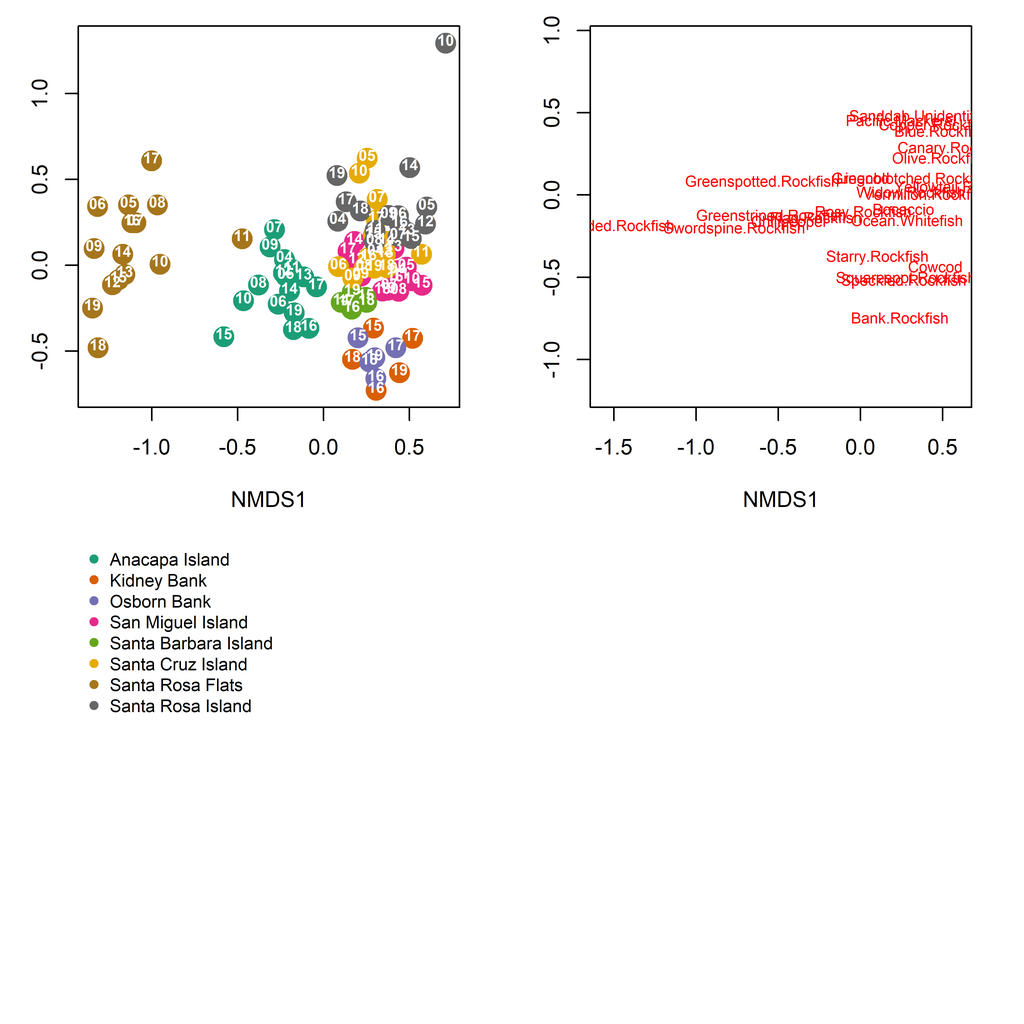

nMDS ordination plots for area-level analyis Number indicate the year of the sample from 2000 on. Thus 10 is 2010.

Here is another plot of the same data by area. I have just separated the plots by area. The data and results are the same as in the previous figure.

I do not see any obvious annual trends overall. I suppose at Anacapa most ‘blob’ years are to the lower right, but that is it. You could look more closely.

So, from the nMDS there are some obvious differences in assemblage structure among sites, but no super obvious year trends.

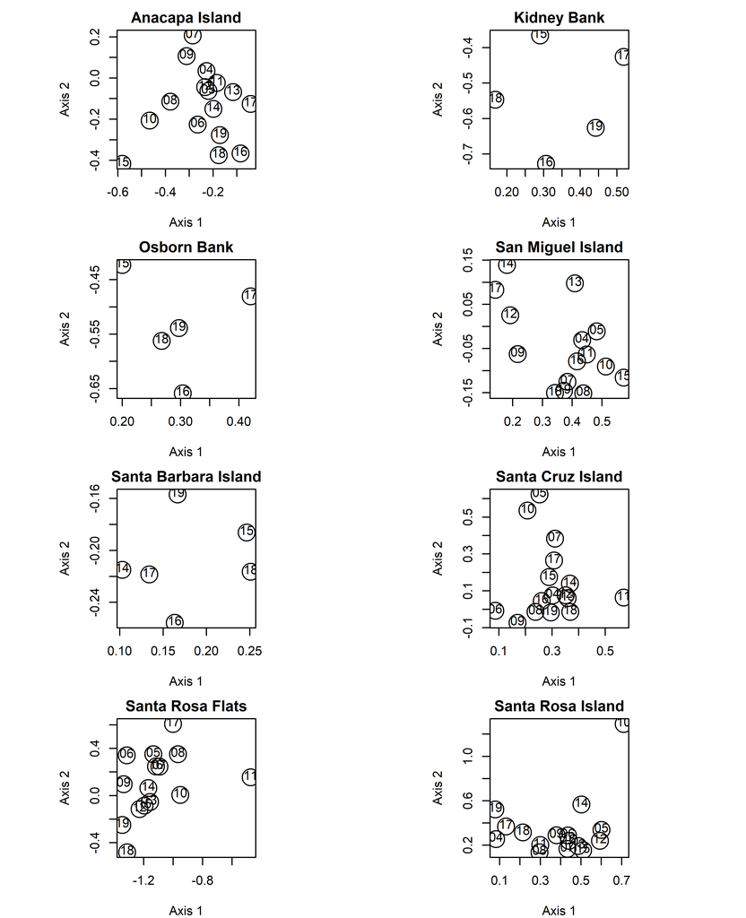

# Canonical analysis of prinicpal coordinates

I also set up a canonical analysis of principal coordinates (CAP). CAP is a constrained ordination. A constrained ordination means that the stats know that sites or some other independent variables constrain the data. Essentially this means that you have an hypothesis or two - eg, Assemblages differ among sites. As a result, the ordination statistics try to draw the axes differently.

```
## Overall classification success (m=10) : 53.8283062645012 percent
## Anacapa Island (n=97) correct: 56.701030927835 percent
## Kidney Bank (n=5) correct: 40 percent
## Osborn Bank (n=10) correct: 40 percent
## San Miguel Island (n=89) correct: 66.2921348314607 percent
## Santa Barbara Island (n=39) correct: 38.4615384615385 percent
## Santa Cruz Island (n=101) correct: 42.5742574257426 percent
## Santa Rosa Flats (n=15) correct: 93.3333333333333 percent
## Santa Rosa Island (n=75) correct: 53.3333333333333 percent
```

The above readout is *classification success*. The stats… 1. Develops a model to classify samples to site based on the assemblage structure of the catch 2. Looks at an individual sample and decides to which site it shoudl be allocated 3. Then checks whether that is correct.

With eight 8 areas, you would expect a 12.5% success rate at random, so the classification success is pretty good, especially for Santa Rosa Flats.

For the CAP, I included Area as a fixed, categorical variable. I did not include year because some areas or many areas had only one ‘sample’ in a given year. That makes it impossible to run the stats. We can still plot the results identifying years and see whether there is any sort of trend, however.

Anderson, M. J., and T. J. Willis. 2003. Canonical analysis of principal coordinates: A useful method of constrained ordination for ecology. Ecology 84:511-525.

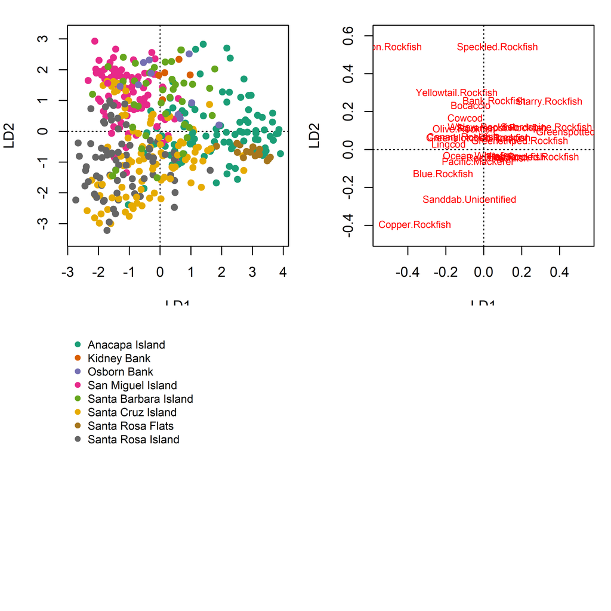

Canonical analysis of principal coordinates. Bray-Curtis distance.

The ordination was significant (p < 0.001 ). I’ve done two plots. The first is the ‘raw’ scores. That is, there is one point for each sample in the original data set. For the second plot, I’ve plotted the centroids and se. It is a bit cleaner and easier to see.

Note, however, that while the CAP analysis was significant, there was also significant multivariate dispersion (p < 0.001), which is more or less multivariate-heterogeneity of variance. This does not ruin the analysis; it must means be cautious in interpretation. The ordinations are pretty clear, so I think it is ok. You can tell, however, that the area over which various sites are spread differs. Nevertheless, the points do not overlap that much for some sites.

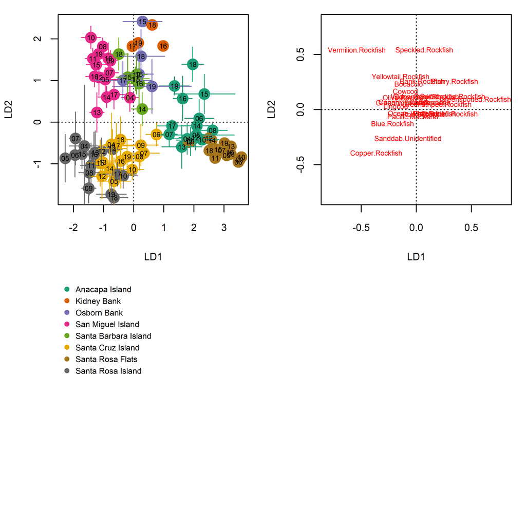

# MARSS analysis - Boaccio population trends

I started messing with some MARSS analyses. We could use this type of analysis to see if population trends are the same at all Areas, in this case for Bocaccio. There aren’t quite enough data for MARSS to work really well. We can’t estimate Q, which is process variance. I haven’t coded in any model selection to test multiple models, but one could.

```
## Success! abstol and log-log tests passed at 1191 iterations.
## Alert: conv.test.slope.tol is 0.5.
## Test with smaller values (<0.1) to ensure convergence.
##
## MARSS fit is
## Estimation method: kem
## Convergence test: conv.test.slope.tol = 0.5, abstol = 0.001
## Estimation converged in 1191 iterations.
## Log-likelihood: -74.09959
## AIC: 170.1992   AICc: 174.0815
##
##                           Estimate
## R.diag                     0.37329
## U.1                        0.00589
## Q.diag                     0.00000
## x0.X.Anacapa Island        1.48819
## x0.X.Kidney Bank           2.53147
## x0.X.Osborn Bank           1.18574
## x0.X.San Miguel Island     1.89162
## x0.X.Santa Barbara Island  1.53424
## x0.X.Santa Cruz Island     1.54915
## x0.X.Santa Rosa Flats      0.65399
## x0.X.Santa Rosa Island     1.02042
## Initial states (x0) defined at t=0
##
## Standard errors have not been calculated.
## Use MARSSparamCIs to compute CIs and bias estimates.
```

```
## [1] 174.0815
```

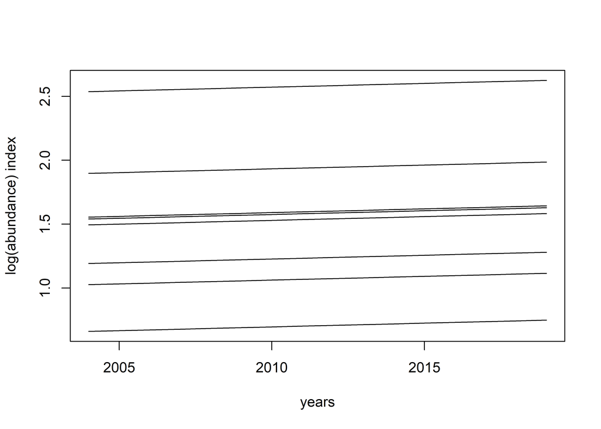

# Dynamic Factor Analysis - Spp Assemblage throug time

I also ran a dynamic factor analysis to look for common trends among species. I averaged species abundance for each year. Thus there is no site-level information in the analysis here. Just Average abundance in a given year. I then ran a dyniamic factor analysis, which is a bit like a PCA but with autocorrelation. That is, the abundance of bocaccio in 2015 is a function of bocaccio abundance in 2014.

This analysis is pretty preliminary. I didn’t run tons of iterations, so many of the models don’t converge.

I did some model fitting and only one trend emerged from the assemblage data. By looking at the loadings table you can see which species were positively correlated with the trend and which wer negatively correlated with the trend. THe loadings (Z) are not actually correlations but the sign gives the direction.

The trend in the figure below suggests that some species have generally increased in abundance through time while others have decreased.

| Table XX. DFA Species loadings Species | Table XX. DFA Species loadings Loading |
| --- | --- |
| Bank.Rockfish | 0.298 |
| Blue.Rockfish | -0.205 |
| Bocaccio | -0.055 |
| Canary.Rockfish | -0.083 |
| Chilipepper | 0.175 |
| Copper.Rockfish | -0.160 |
| Cowcod | 0.202 |
| Flag.Rockfish | -0.101 |
| Greenblotched.Rockfish | 0.122 |
| Greenspotted.Rockfish | -0.033 |
| Greenstriped.Rockfish | 0.224 |
| Halfbanded.Rockfish | 0.242 |
| Lingcod | 0.019 |
| Ocean.Whitefish | 0.207 |
| Olive.Rockfish | -0.095 |
| Pacific.Mackerel | 0.220 |
| Rosy.Rockfish | 0.131 |
| Sanddab.Unidentified | 0.130 |
| Speckled.Rockfish | 0.278 |
| Squarespot.Rockfish | 0.218 |
| Starry.Rockfish | 0.232 |
| Swordspine.Rockfish | 0.254 |
| Vermilion.Rockfish | 0.019 |
| Widow.Rockfish | -0.203 |
| Yellowtail.Rockfish | -0.177 |

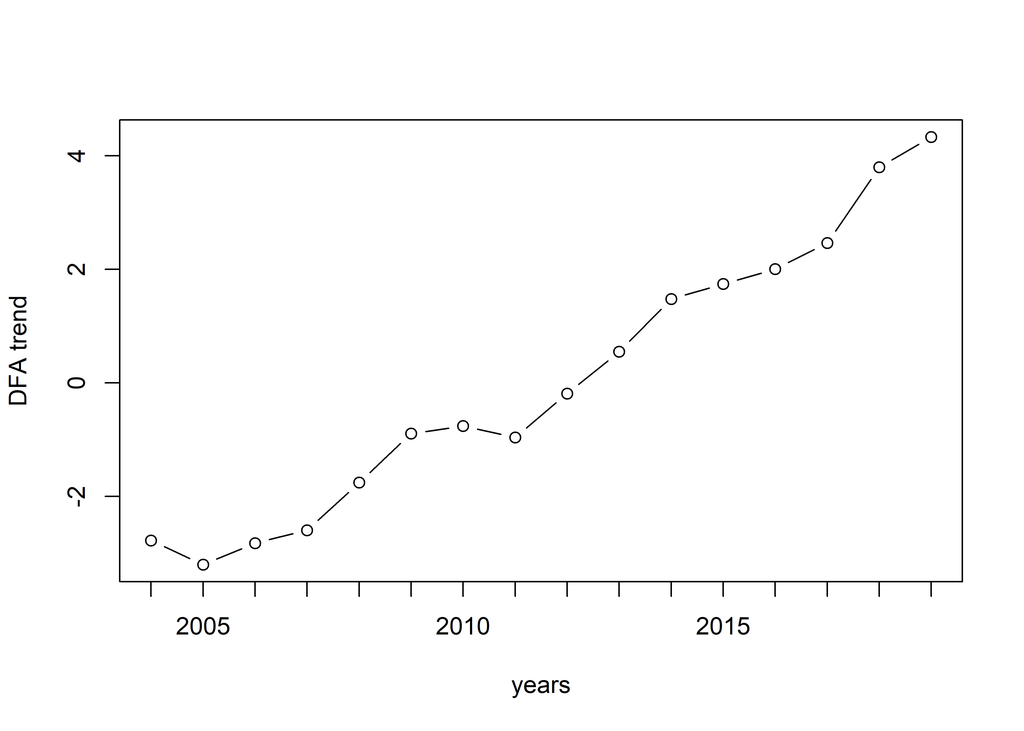